# Collaborative Data Activity - Categorical Outcomes

J Bhanji

2024-04-24

## General process to analyze categorical outcomes with categorical predictors

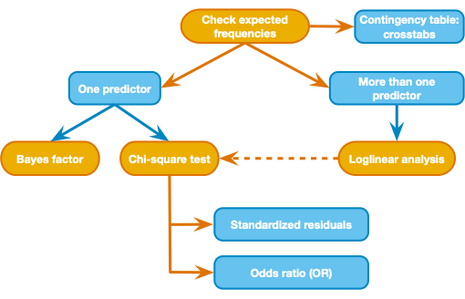

Categorical outcome decision process

## Step 0 - Install a package

- This activity makes use of two new packages: “janitor” (for data cleaning), and “vcd” (for odds ratio calculation)

## Step 1 - Import the data

- we make use of the “janitor” package in this doc
- allow “na”, “n/a”, etc. as missing values
- create unique id for reach row
- here’s a link to the tsv file if you want to check it out on your own

```r
pub_tib <- readr::read_delim("data/Dataset-PublicationStatistics-2024.tsv",
                             na=c("n/a","na","N/A","NA","Na","N/a",""),
                             delim = "\t", show_col_types = FALSE) |>
  janitor::clean_names() |>  #fixes the column names
  select(-student_name,-citation,-doi) |>  #drop unused columns
  janitor::remove_empty(which = "rows") |>  # drop empty rows
  mutate(id = row_number(), .before = 1) |>   #add a column with id for each row
  mutate(across(where(is.character), str_trim)) |> #remove trailing/leading whitespace
  mutate(across(where(is.character), tolower)) #make all text columns lowercase
```

## Step 2 - clean the data and set variable types

Check values of our variables:  
1. binary variables (reported yes/no): store as factor and check levels  
2. numerical (e.g., participants): convert “no” to NA and store as numerical  
3. field: since one entry can belong to multiple fields, we create a series of dummy coded variables `soc`,`cog`,`dev`, etc where a row gets a value of 1 if the given field appears in the `field` column. there is some variance in how fields are entered (“social”/“soc”, “cognitive”/“cog) so we’ll just check for a key part of text for each.  
4. sample_size_justification: store as factor and check levels

```r
#fix typos where "no" was entered as "on"
pub_tib <- pub_tib |> mutate(
  income_or_ses_reported = str_replace(income_or_ses_reported, pattern = "on", replacement = "no")
)

#1. binary variables - using "factor" instead of "as_factor" because it will put
#   the levels in alpha order - NA values are recoded as "no"
pub_tib <- pub_tib |> mutate(
  race_ethn_reported = factor(replace_na(race_ethn_reported,"no")),
  income_or_ses_reported = factor(replace_na(income_or_ses_reported,"no")),
  location_reported = factor(replace_na(location_reported,"no")),
  general_sample = factor(replace_na(general_sample,"no")),
  sample_size_justification = factor(sample_size_justification)
)
pub_tib |> select(race_ethn_reported:general_sample,sample_size_justification) |> purrr::map(levels)
```

```
## $race_ethn_reported
## [1] "no"  "yes"
##
## $income_or_ses_reported
## [1] "no"  "yes"
##
## $location_reported
## [1] "no"  "yes"
##
## $general_sample
## [1] "no"  "yes"
##
## $sample_size_justification
## [1] "a-priori"         "accuracy"         "constraints"      "heuristics"
## [5] "no-justification" "no-statement"     "population"
```

```r
pub_tib |> count(race_ethn_reported)
```

```
## # A tibble: 2 × 2
##   race_ethn_reported     n
##   <fct>              <int>
## 1 no                   197
## 2 yes                  109
```

```r
pub_tib |> count(income_or_ses_reported)
```

```
## # A tibble: 2 × 2
##   income_or_ses_reported     n
##   <fct>                  <int>
## 1 no                       233
## 2 yes                       73
```

```r
pub_tib |> count(location_reported)
```

```
## # A tibble: 2 × 2
##   location_reported     n
##   <fct>             <int>
## 1 no                   97
## 2 yes                 209
```

```r
pub_tib |> count(general_sample)
```

```
## # A tibble: 2 × 2
##   general_sample     n
##   <fct>          <int>
## 1 no                93
## 2 yes              213
```

```r
pub_tib |> count(sample_size_justification)
```

```
## # A tibble: 8 × 2
##   sample_size_justification     n
##   <fct>                     <int>
## 1 a-priori                     26
## 2 accuracy                      7
## 3 constraints                  13
## 4 heuristics                   11
## 5 no-justification             57
## 6 no-statement                 81
## 7 population                    5
## 8 <NA>                        106
```

```r
#2. Numerical variables: participants_male and participants_female are stored as chr
#   use parse_number() and any non-numeric values will get NA
#   but there's an inconsistency in reporting NA/no versus 0 - we would need to
#   resolve the inconsistency to make use of that data
pub_tib <- pub_tib |> mutate(
  participants_n = parse_number(stringr::word(participants_n), na = "no"),
  participants_male = parse_number(stringr::word(participants_male), na = "no"),
  participants_female = parse_number(stringr::word(participants_female), na = "no"),
  participants_nonbin = parse_number(stringr::word(participants_nonbin), na = "no")
)
pub_tib |> select(participants_n:participants_nonbin) |> psych::describe()
```

```
##                     vars   n    mean      sd median trimmed    mad min    max
## participants_n         1 306 1143.83 8356.92    112  200.83 127.50   7 138625
## participants_male      2 264  506.53 3847.89     45   93.28  53.37   0  61226
## participants_female    3 268  698.06 5137.24     62  108.82  72.65   0  77399
## participants_nonbin    4  48    3.56   11.76      0    0.88   0.00   0     75
##                      range  skew kurtosis     se
## participants_n      138618 14.85   237.47 477.73
## participants_male    61226 14.94   231.95 236.82
## participants_female  77399 13.08   185.72 313.81
## participants_nonbin     75  4.90    25.82   1.70
```

```r
#3. check out "field"
pub_tib |> janitor::tabyl(field) #or use count(field)
```

```
##                       field  n     percent
##          clinical, cog, dev  1 0.003267974
##                         cog 36 0.117647059
##                 cog , other  1 0.003267974
##                    cog, dev 14 0.045751634
##               cog, dev, soc  1 0.003267974
##                  cog, neuro 19 0.062091503
##             cog, neuro, dev  7 0.022875817
##             cog, neuro, soc  1 0.003267974
##                  cog, other  2 0.006535948
##                    cog, soc  6 0.019607843
##                     cog,dev  5 0.016339869
##                   cog,neuro 45 0.147058824
##               cog,neuro,dev  4 0.013071895
##              cog,neuro,pers  1 0.003267974
##                   cog,other  1 0.003267974
##                     cog,soc  9 0.029411765
##                 cog,soc,dev  1 0.003267974
##                      conbeh 14 0.045751634
##                         dev  7 0.022875817
##                    dev, cog  5 0.016339869
##                  dev, other  1 0.003267974
##                    dev, soc  1 0.003267974
##                     dev,cog  2 0.006535948
##               dev,cog,neuro  2 0.006535948
##                   dev,neuro  1 0.003267974
##               dev,neuro,cog  1 0.003267974
##            dev,neuro,social  1 0.003267974
##                     dev,soc  1 0.003267974
##                  dev,social  2 0.006535948
##                       neuro 20 0.065359477
##            neuro, cognitive  2 0.006535948
##                   neuro,cog  2 0.006535948
##                   neuro,dev  1 0.003267974
##                   neuro,soc  1 0.003267974
##                       other 14 0.045751634
##                  other, dev  2 0.006535948
##                other, neuro  1 0.003267974
##                        pers  7 0.022875817
##                   pers, soc  6 0.019607843
##              pers, soc, cog  1 0.003267974
##              pers,quant,cog  2 0.006535948
##          psych, bio, social  1 0.003267974
##            psych, cognitive  2 0.006535948
##           psych, soc, neuro  1 0.003267974
##               psych, social  3 0.009803922
##  psych, social, personality  2 0.006535948
##                         soc 31 0.101307190
##                  soc & pers  1 0.003267974
##                    soc, cog  3 0.009803922
##                   soc, pers  1 0.003267974
##               soc,cog,neuro  2 0.006535948
##                     soc,dev  1 0.003267974
##                   soc,neuro  1 0.003267974
##                      social  5 0.016339869
##            social,cog,neuro  1 0.003267974
```

```r
# now dummy code the "field" variable, allowing for multiple fields per entry
pub_tib <- pub_tib |>
  mutate(
    soc = if_else(str_detect(field,"soc"), 1, 0),
    cog = if_else(str_detect(field,"cog"), 1, 0),
    dev = if_else(str_detect(field,"dev"), 1, 0),
    pers = if_else(str_detect(field,"pers"), 1, 0),
    conbeh = if_else(str_detect(field,"con"), 1, 0),
    neuro = if_else(str_detect(field,"neuro"), 1, 0),
    quant = if_else(str_detect(field,"quant"), 1, 0),
    other = if_else(str_detect(field,"other"), 1, 0),
    #field_combo = ""
  )
# print counts of each field
pub_tib |> select(soc:other) |> colSums(na.rm = TRUE)
```

```
##    soc    cog    dev   pers conbeh  neuro  quant  other
##     84    179     61     21     14    114      2     22
```

```r
# # only 2 quant cases so drop that column
# pub_tib <- pub_tib |> select(-quant)
```